# DATA621: Final Project

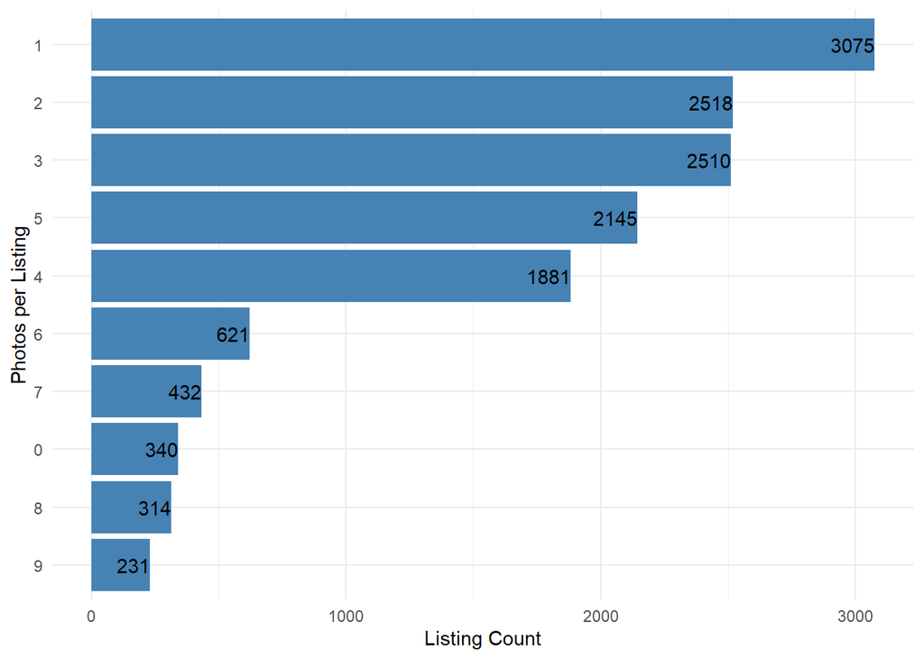

```r
train_data %>%
  group_by(PhotoAmt) %>%
  summarise(Count = length(PhotoAmt)) %>%
  arrange(desc(Count)) %>%
  top_n(10) %>%
  ggplot(aes(x=fct_reorder(factor(PhotoAmt),Count),
             y= Count))+
  geom_col(position="dodge", fill= "steelblue")+
  geom_text(aes(label = Count, hjust = 1))+
  coord_flip()+
  labs(x= "Photos per Listing", y = "Listing Count")+
  theme_minimal()
```

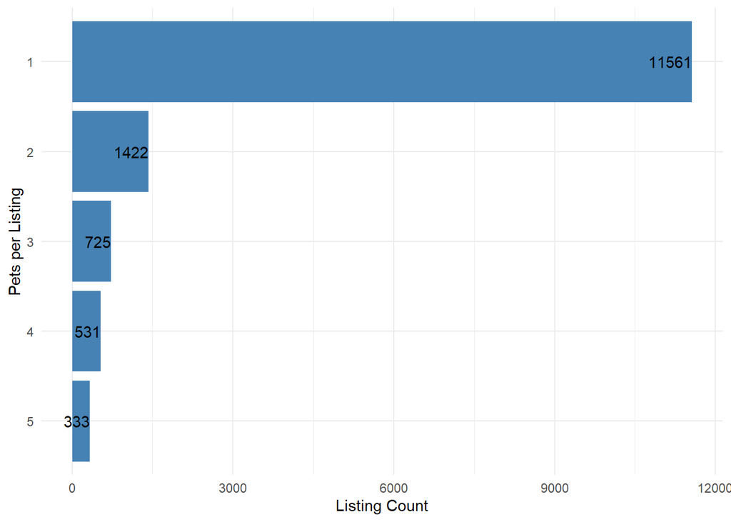

```r
train_data %>%
  group_by(Quantity) %>%
  summarise(Count = length(Quantity)) %>%
  arrange(desc(Count)) %>%
  top_n(5)%>%
  ggplot(aes(x=fct_reorder(factor(Quantity),Count),
             y= Count))+
  geom_col(position="dodge", fill= "steelblue")+
  geom_text(aes(label = Count, hjust = 1))+
  coord_flip()+
  labs(x= "Pets per Listing", y = "Listing Count")+
  theme_minimal()
```

### Distributions of Numeric Variables

Here we are subsetting our numeric predictor variables to check their distributions.

```r
#subset our 3 vars
distributions <- train_data %>%
  keep(is.numeric)
```

Next we check if the variables contain any NA values.

```r
colSums(is.na(distributions))
```

```
## Quantity      Fee PhotoAmt AgeYears
##        0        0        0        0
```

```r
#plot
distributions %>%
  gather(variable, value, 1:4) %>%
  ggplot(aes(value)) +
    facet_wrap(~variable, scales = "free") +
    geom_density(fill = "steelblue", alpha=0.9, color="steelblue") +
    geom_histogram(aes(y=..density..), alpha=0.2, fill = "lightblue", color="lightblue", position="identity") +
    theme_minimal()
```

[figure not shown]

```r
#box plots
distributions %>%
  gather() %>%
  ggplot(aes(value)) +
  facet_wrap(~ key, scales = "free") +
  geom_boxplot(fill = "steelblue", color="black", outlier.colour="red", outlier.shape=16,
             outlier.size=2, notch=FALSE) +
  theme_minimal()
```

[figure not shown]

```r
#box plots
distributions %>%
  gather() %>%
  ggplot(aes(value)) +
  facet_wrap(~ key, scales = "free") +
  geom_boxplot(fill = "steelblue", color="black", outlier.colour="red", outlier.shape=16,
             outlier.size=2, notch=FALSE) +
  theme_minimal()
```

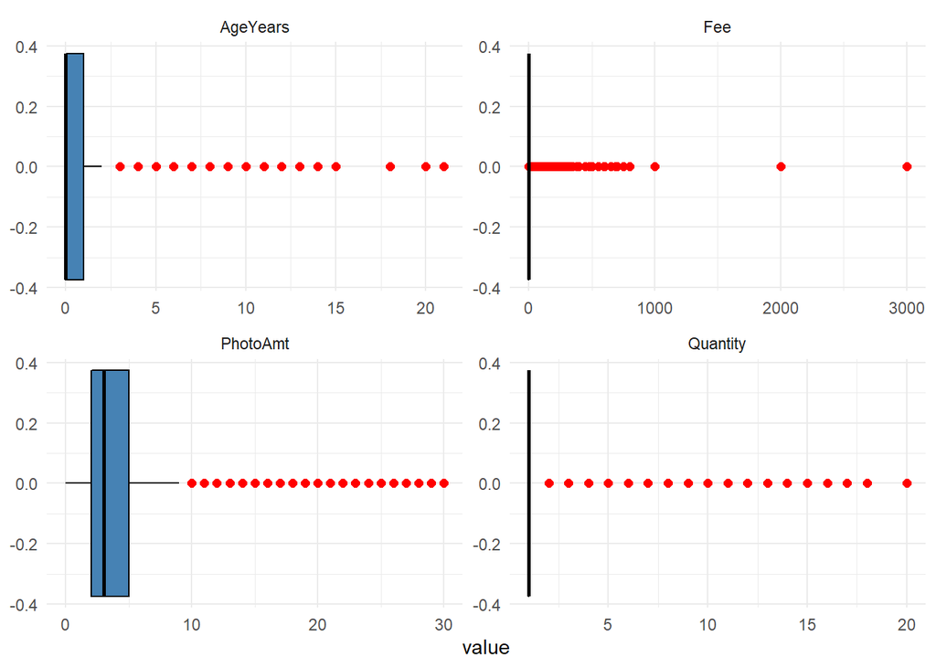

```r
#stats
descr(distributions,
  headings = FALSE, #remove headings#
  transpose = FALSE #TRUE allows for better display due to large amount of variables
  ) %>%
  kbl(caption = "Univariate Descriptive Statistics - Training Data Set") %>%
  kable_styling(bootstrap_options = c("striped", "hover", "condensed"))
```

Univariate Descriptive Statistics - Training Data Set

|  | AgeYears | Fee | PhotoAmt | Quantity |
| --- | --- | --- | --- | --- |
| Mean | 7.453963e-01 | 21.260342 | 3.888911e+00 | 1.576128 |
| Std.Dev | 1.574604e+00 | 78.424238 | 3.487732e+00 | 1.472647 |
| Min | 0.000000e+00 | 0.000000 | 0.000000e+00 | 1.000000 |
| Q1 | 0.000000e+00 | 0.000000 | 2.000000e+00 | 1.000000 |
| Median | 0.000000e+00 | 0.000000 | 3.000000e+00 | 1.000000 |
| Q3 | 1.000000e+00 | 0.000000 | 5.000000e+00 | 1.000000 |
| Max | 2.100000e+01 | 3000.000000 | 3.000000e+01 | 20.000000 |
| MAD | 0.000000e+00 | 0.000000 | 2.965200e+00 | 0.000000 |
| IQR | 1.000000e+00 | 0.000000 | 3.000000e+00 | 0.000000 |
| CV | 2.112439e+00 | 3.688757 | 8.968404e-01 | 0.934345 |
| Skewness | 3.507133e+00 | 8.919192 | 2.860996e+00 | 4.598680 |
| SE.Skewness | 2.000600e-02 | 0.020006 | 2.000600e-02 | 0.020006 |
| Kurtosis | 1.836015e+01 | 191.578844 | 1.264557e+01 | 34.064552 |
| N.Valid | 1.498800e+04 | 14988.000000 | 1.498800e+04 | 14988.000000 |
| Pct.Valid | 1.000000e+02 | 100.000000 | 1.000000e+02 | 100.000000 |

### Transformations of numeric variables

Next we will take transformations of the variables reviewed above to see if the transformed variables are worth looking into and using for our model.

#### Log Transformations

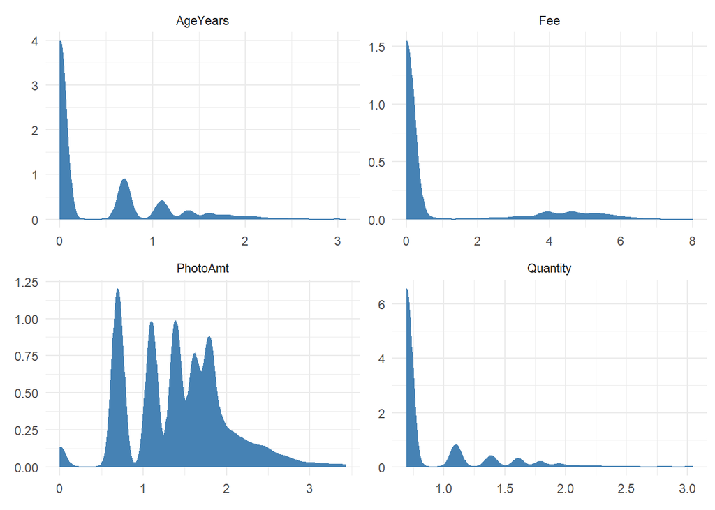

```r
log_distributions <- log(distributions + 1)

# Histograms of log transformed numeric variables
log_distributions %>%
  gather(variable, value, 1:4) %>%
  ggplot(., aes(value)) +
  geom_density(fill = "steelblue", color="steelblue") +
  facet_wrap(~variable, scales ="free", ncol = 2) +
  labs(x = element_blank(), y = element_blank()) +
  theme_minimal()
```

#### Square Root transformations

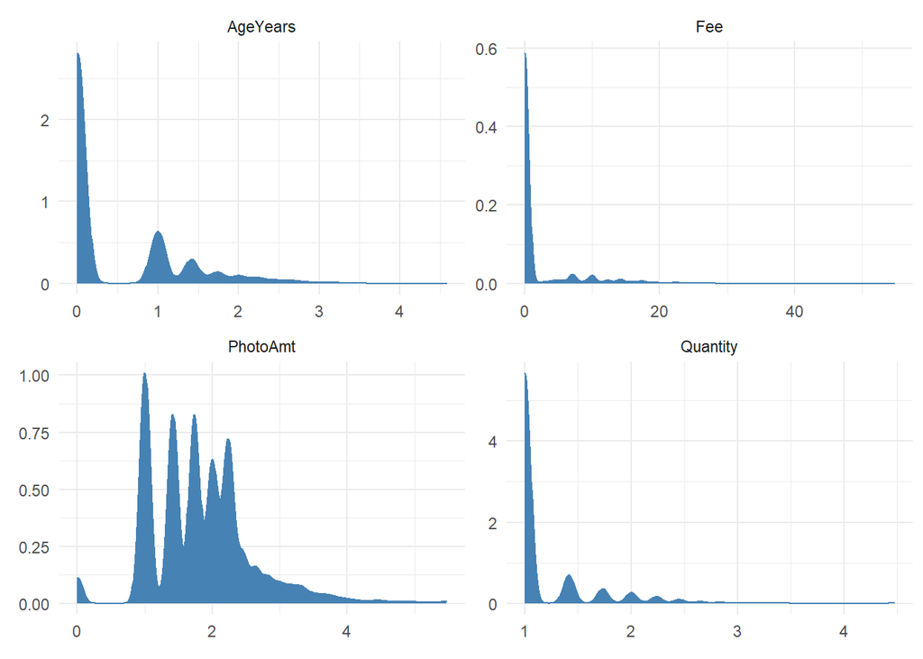

```r
sqrt_distributions <- sqrt(distributions)

sqrt_distributions %>%
  gather(variable, value, 1:4) %>%
  ggplot(., aes(value)) +
  geom_density(fill = "steelblue", color="steelblue") +
  facet_wrap(~variable, scales ="free", ncol = 2) +
  labs(x = element_blank(), y = element_blank()) +
  theme_minimal()
```

#### Cube root transformations

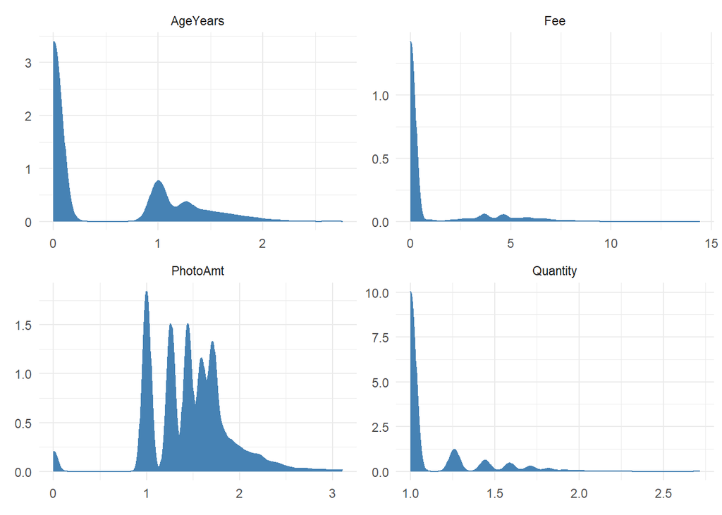

```r
cbrt_distributions <- (distributions)^(1/3)

cbrt_distributions %>%
  gather(variable, value, 1:4) %>%
  ggplot(., aes(value)) +
  geom_density(fill = "steelblue", color="steelblue") +
  facet_wrap(~variable, scales ="free", ncol = 2) +
  labs(x = element_blank(), y = element_blank()) +
  theme_minimal()
```

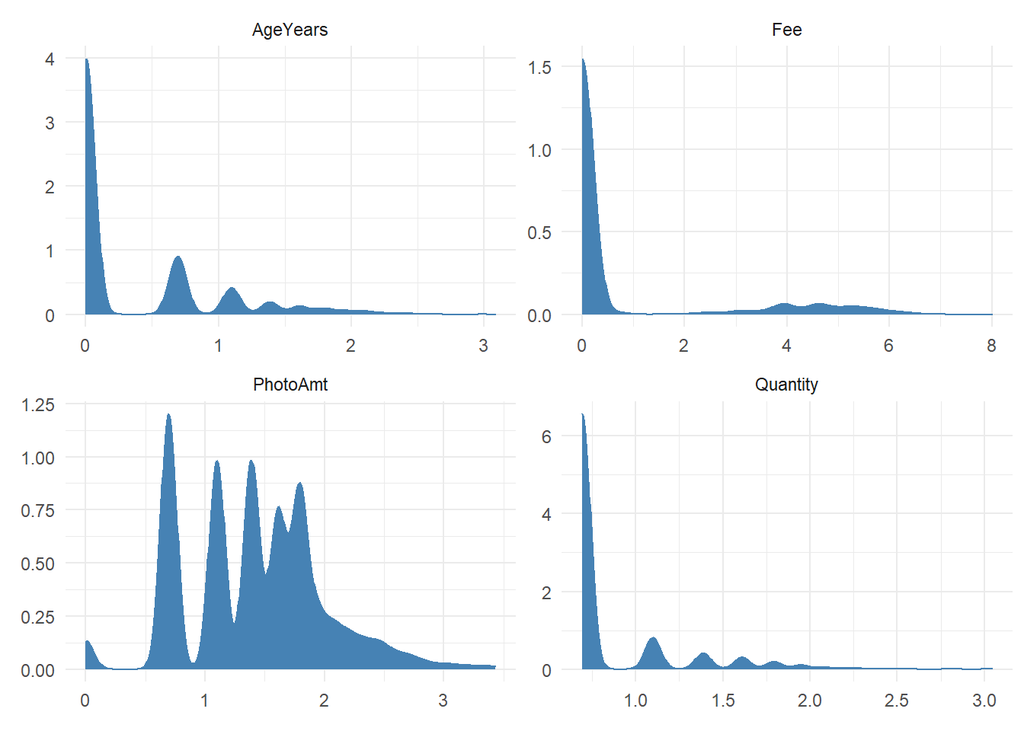

```r
log_distributions <- log(distributions + 1)

# Histograms of log transformed numeric variables
log_distributions %>%
  gather(variable, value, 1:4) %>%
  ggplot(., aes(value)) +
  geom_density(fill = "steelblue", color="steelblue") +
  facet_wrap(~variable, scales ="free", ncol = 2) +
  labs(x = element_blank(), y = element_blank()) +
  theme_minimal()
```

#### Square Root transformations

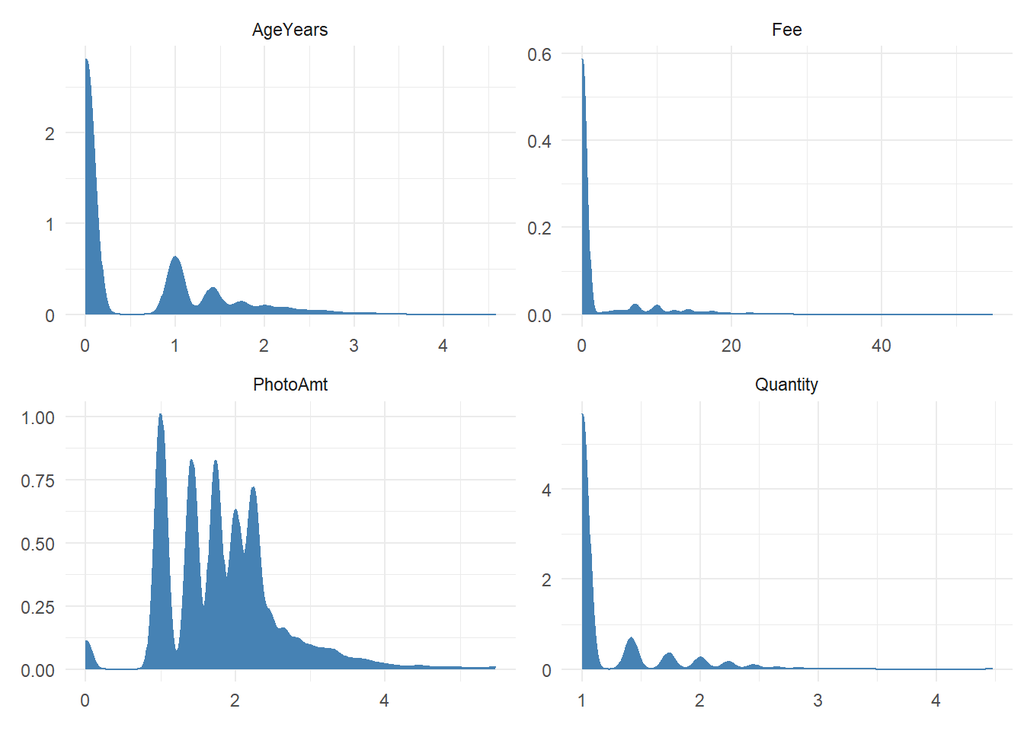

```r
sqrt_distributions <- sqrt(distributions)

sqrt_distributions %>%
  gather(variable, value, 1:4) %>%
  ggplot(., aes(value)) +
  geom_density(fill = "steelblue", color="steelblue") +
  facet_wrap(~variable, scales ="free", ncol = 2) +
  labs(x = element_blank(), y = element_blank()) +
  theme_minimal()
```

#### Cube root transformations

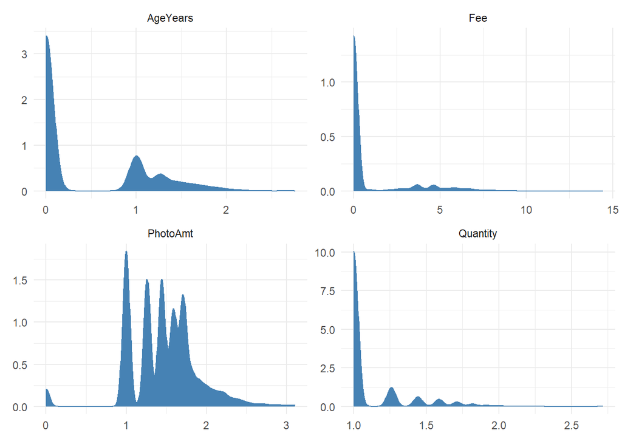

```r
cbrt_distributions <- (distributions)^(1/3)

cbrt_distributions %>%
  gather(variable, value, 1:4) %>%
  ggplot(., aes(value)) +
  geom_density(fill = "steelblue", color="steelblue") +
  facet_wrap(~variable, scales ="free", ncol = 2) +
  labs(x = element_blank(), y = element_blank()) +
  theme_minimal()
```

Based on the above, all variables are still heavily right skewed with the exception of `PhotoAmt` which made some improvement, but still not normally distributed.

### Correlation Plot

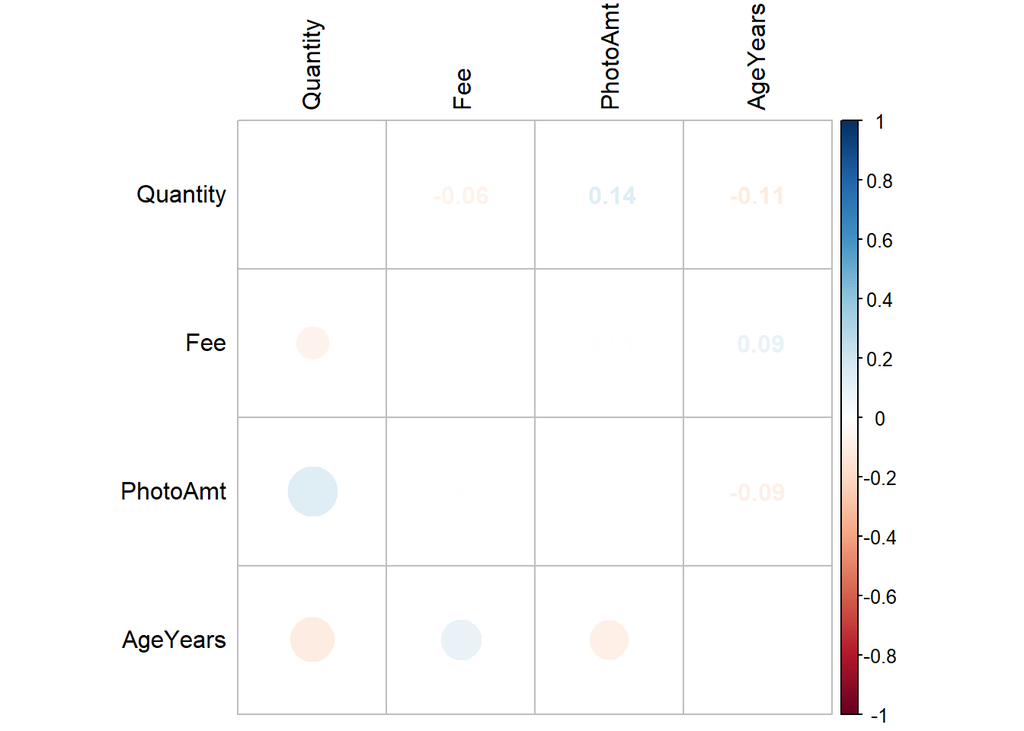

```r
numeric_values <- train_data

numeric_values<- numeric_values %>%
  select_if(is.numeric)

train_cor <- cor(numeric_values)
corrplot.mixed(train_cor, tl.col = 'black', tl.pos = 'lt', upper = "number", lower="circle")
```

## Build Model

Below we create a new feature based on the response variable `euth_risk`, which is a tri-level variable to condense the original `AdoptionSpeed`. [^1] [^2]

```r
train_data$euth_risk<- fct_collapse(train_data$AdoptionSpeed,
                              'Low' = c("0", "1"),
                              'Medium' = c("2","3"),
                              'High' = "4")
levels(train_data$euth_risk)
```

```
## [1] "Low"    "Medium" "High"
```

```r
#removing breedname as it has too many factor levels
train_data <- train_data %>%
  dplyr::select(-breedname)
```

```r
summary(train_data)
```

```
##   Type         Gender        Color1          MaturitySize    FurLength
##  Dog:8128   Male  :5535   Black :7425   Small      : 3393   Short :8804
##  Cat:6860   Female:7274   Brown :3747   Medium     :10302   Medium:5360
##             Mixed :2179   Golden: 947   Large      : 1260   Long  : 824
##                           Yellow: 634   Extra Large:   33
##                           Cream : 884
##                           Gray  : 684
##                           White : 667
##     Vaccinated       Dewormed       Sterilized               Health
##  Yes     :5896   Yes     :8394   Yes     : 3101   Healthy       :14473
##  No      :7224   No      :4813   No      :10072   Minor Injury  :  481
##  Not Sure:1868   Not Sure:1781   Not Sure: 1815   Serious Injury:   34
##
##
##
##
##     Quantity           Fee             PhotoAmt      AdoptionSpeed
##  Min.   : 1.000   Min.   :   0.00   Min.   : 0.000   0: 410
##  1st Qu.: 1.000   1st Qu.:   0.00   1st Qu.: 2.000   1:3090
##  Median : 1.000   Median :   0.00   Median : 3.000   2:4036
##  Mean   : 1.576   Mean   :  21.26   Mean   : 3.889   3:3257
##  3rd Qu.: 1.000   3rd Qu.:   0.00   3rd Qu.: 5.000   4:4195
##  Max.   :20.000   Max.   :3000.00   Max.   :30.000
##
##     AgeYears       NumColors AllMeds  purebreed  solidcolor   euth_risk
##  Min.   : 0.0000   1:4470    3:2436   No :5927   No : 4470   Low   :3500
##  1st Qu.: 0.0000   2:6131    4:3112   Yes:9061   Yes:10518   Medium:7293
##  Median : 0.0000   3:4387    5:2860                          High  :4195
##  Mean   : 0.7454             6:4601
##  3rd Qu.: 1.0000             7: 496
##  Max.   :21.0000             8: 480
##                              9:1003
```

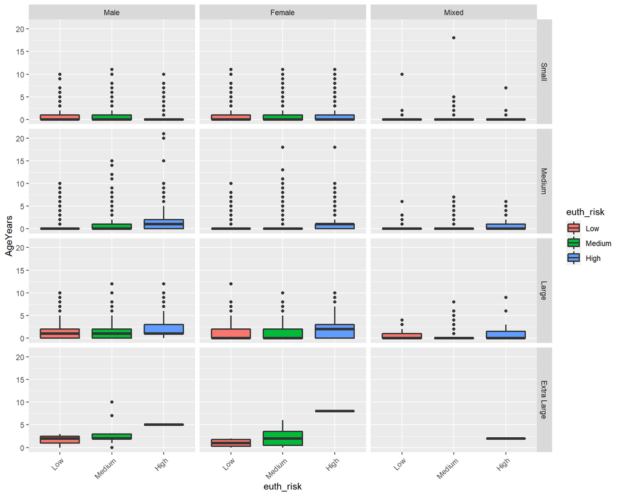

```r
ggplot(train_data, aes(x = euth_risk, y = AgeYears, fill = euth_risk)) +
  geom_boxplot(size = .75) +   facet_grid(MaturitySize ~ Gender, margins = FALSE) +
  theme(axis.text.x = element_text(angle = 45, hjust = 1, vjust = 1))
```

```r
subeset <- train_data %>%
  dplyr::select('MaturitySize','Type', 'euth_risk')

#class(subeset)

table1 <- addmargins(table(subeset$MaturitySize,subeset$Type, subeset$euth_risk))

#print.table(table1)

df <- as.data.frame(table1)

df <- subset(df, Var1 != "Sum" & Var2 != "Sum" & Var3 != "Sum") # & Var2 != "Mixed"
```

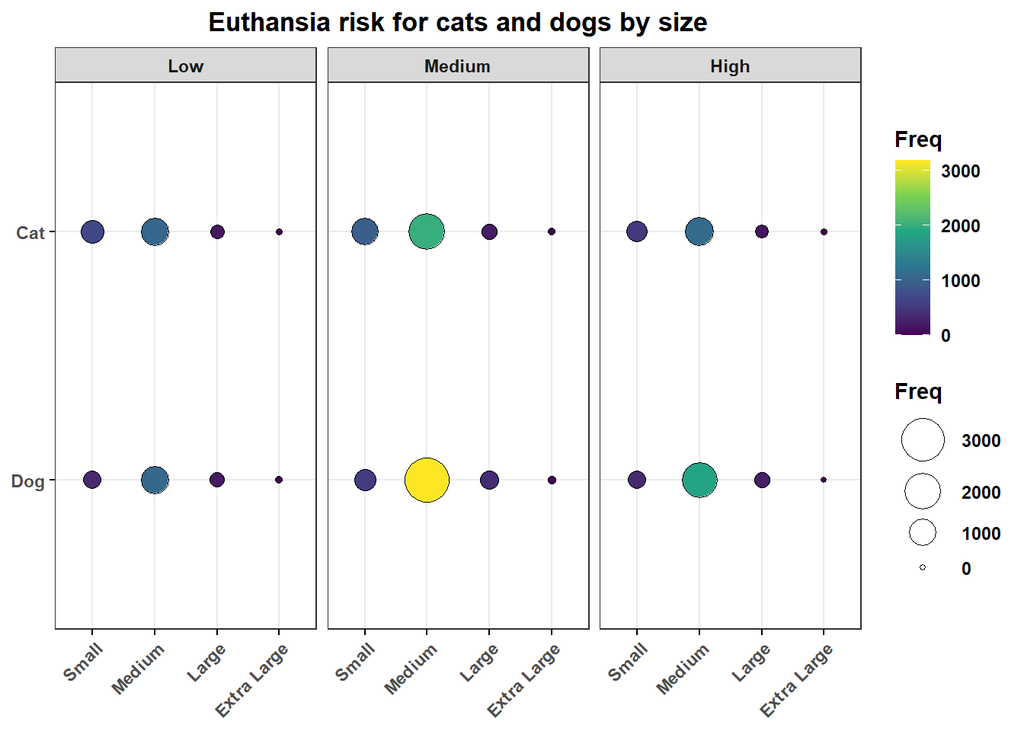

```r
library(ggpubr)
ggballoonplot(df, x= 'Var1', y='Var2', size = "Freq",
              fill = "Freq", facet.by = "Var3",
              ggtheme = theme_bw())+
  scale_fill_viridis_c(option = "D")+
  ggtitle("Euthansia risk for cats and dogs by size")+
  theme(text = element_text(face = "bold"),
    plot.title = element_text(hjust = 0.5, face="bold"))
```

### ORDINAL LOGISTIC REGRESSION

The following models will be created using ordinal logisitic regression given the nature of the response variable as it can be considered an ordinal factor. [^3]

#### Selecting an ordered variable

Below we run two null models, one with our original response variable `AdoptionSpeed`, and one with our created response variable `euth_risk`.

```r
null_model2 <- polr(AdoptionSpeed ~ 1 , train_data, Hess=TRUE)

summary(null_model2)
```

```r
null_model2 <- polr(AdoptionSpeed ~ 1 , train_data, Hess=TRUE)

summary(null_model2)
```

[output not shown]

```r
null_model <- polr(euth_risk ~ 1 , train_data, Hess=TRUE)

summary(null_model)
```

```r
null_model <- polr(euth_risk ~ 1 , train_data, Hess=TRUE)

summary(null_model)
```

```
## Call:
## polr(formula = euth_risk ~ 1, data = train_data, Hess = TRUE)
##
## No coefficients
##
## Intercepts:
##             Value    Std. Error t value
## Low|Medium   -1.1885   0.0193   -61.5599
## Medium|High   0.9450   0.0182    51.9398
##
## Residual Deviance: 31371.67
## AIC: 31375.67
```

AIC is used to compare different possible models and determine which one is the best fit for the data. By itself, the AIC score is not of much use unless it is compared with the AIC score of a competing model.

The model with the lower AIC score is expected to strike a superior balance between its ability to fit the data set and its ability to avoid over-fitting the data set. [^4]

Using the AIC value, we see the model using the `euth-risk` may be a better fit.

```r
model_1 <- polr(euth_risk~ Type+(Gender+Color1+MaturitySize+
                                 FurLength+Health+Quantity+
                                 Fee+PhotoAmt+AgeYears+
                                 NumColors+purebreed+
                                 Vaccinated+Dewormed+Sterilized),
              train_data,
              Hess=TRUE)

summary(model_1)
```

```r
model_1 <- polr(euth_risk~ Type+(Gender+Color1+MaturitySize+
                                 FurLength+Health+Quantity+
                                 Fee+PhotoAmt+AgeYears+
                                 NumColors+purebreed+
                                 Vaccinated+Dewormed+Sterilized),
              train_data,
              Hess=TRUE)

summary(model_1)
```

```
## Call:
## polr(formula = euth_risk ~ Type + (Gender + Color1 + MaturitySize +
##     FurLength + Health + Quantity + Fee + PhotoAmt + AgeYears +
##     NumColors + purebreed + Vaccinated + Dewormed + Sterilized),
##     data = train_data, Hess = TRUE)
##
## Coefficients:
##                             Value Std. Error  t value
## TypeCat                  0.719950  0.0538572  13.3678
## GenderFemale             0.168204  0.0346072   4.8604
## GenderMixed              0.069992  0.0650576   1.0758
## Color1Brown             -0.052458  0.0400499  -1.3098
## Color1Golden            -0.075434  0.0676641  -1.1148
## Color1Yellow             0.082996  0.0813784   1.0199
## Color1Cream             -0.378298  0.0707844  -5.3444
## Color1Gray              -0.141022  0.0810344  -1.7403
## Color1White             -0.338424  0.0856518  -3.9512
## MaturitySizeMedium       0.203541  0.0400400   5.0835
## MaturitySizeLarge        0.013530  0.0658124   0.2056
## MaturitySizeExtra Large -0.438712  0.3226675  -1.3596
## FurLengthMedium         -0.167765  0.0335427  -5.0015
## FurLengthLong           -0.815745  0.0746231 -10.9315
## HealthMinor Injury       0.295071  0.0914882   3.2252
## HealthSerious Injury     0.550822  0.3273700   1.6826
## Quantity                 0.129791  0.0155820   8.3295
## Fee                      0.001044  0.0002173   4.8042
## PhotoAmt                -0.027784  0.0044697  -6.2161
## AgeYears                 0.147105  0.0126369  11.6409
## NumColors2              -0.120916  0.0410408  -2.9462
## NumColors3              -0.122398  0.0489668  -2.4996
## purebreedYes            -1.108769  0.0544846 -20.3501
## VaccinatedNo            -0.268332  0.0471178  -5.6949
## VaccinatedNot Sure      -0.081869  0.0918475  -0.8914
## DewormedNo               0.069265  0.0457302   1.5146
## DewormedNot Sure         0.054684  0.0926866   0.5900
## SterilizedNo            -0.752387  0.0465352 -16.1681
## SterilizedNot Sure      -0.194802  0.0686732  -2.8366
##
## Intercepts:
##             Value    Std. Error t value
## Low|Medium   -2.0622   0.0786   -26.2414
## Medium|High   0.2620   0.0765     3.4250
##
## Residual Deviance: 29726.22
## AIC: 29788.22
```

### Assumptions: Detecting Multicollinearity

The R function vif() [car package] can be used to detect multicollinearity[^5] in a regression model:

```r
car::vif(model_1)
```

[output not shown]

```r
car::vif(model_1)
```

```
##                  GVIF Df GVIF^(1/(2*Df))
## Type         2.933667  1        1.712795
## Gender       1.968761  2        1.184536
## Color1       1.529770  6        1.036061
## MaturitySize 1.174359  3        1.027149
## FurLength    1.138186  2        1.032888
## Health       1.032616  2        1.008056
## Quantity     1.937129  1        1.391808
## Fee          1.125602  1        1.060944
## PhotoAmt     1.063591  1        1.031305
## AgeYears     1.482378  1        1.217530
## NumColors    1.544444  2        1.114790
## purebreed    2.870114  1        1.694141
## Vaccinated   7.000083  2        1.626581
## Dewormed     6.222841  2        1.579418
## Sterilized   1.971121  2        1.184891
```

### Dealing with multicollinearity

In this section, we’ll update our model by removing the the predictor variables with high VIF values:

VIF score for the predictor variables `Vaccinated` and `Dewormed` is high (VIF = 7.0, 6.2). This might be problematic. As such we will remove them and replace the two with `AllMeds` Since the `AllMeds` variable is a combination of `Vaccinated`, `Dewormed`, and `Steriliezed`, `Sterilized` will also be removed.

```r
model_2 <- polr(euth_risk~ Type+(Gender+Color1+MaturitySize+
                                 FurLength+Health+Quantity+
                                 Fee+PhotoAmt+AgeYears+
                                 NumColors+purebreed+
                                 AllMeds),
              train_data,
              Hess=TRUE)

summary(model_2)
```

```r
model_2 <- polr(euth_risk~ Type+(Gender+solidcolor+Color1+MaturitySize+
                                 FurLength+Health+Quantity+
                                 Fee+PhotoAmt+AgeYears+
                                purebreed+
                                 AllMeds),
              train_data,
              Hess=TRUE)

summary(model_2)
```

[output not shown]

```r
car::vif(model_2)
```

[output not shown]

```r
car::vif(model_2)
```

```
##                  GVIF Df GVIF^(1/(2*Df))
## Type         2.865737  1        1.692849
## Gender       1.938017  2        1.179884
## solidcolor   1.323522  1        1.150444
## Color1       1.460322  6        1.032058
## MaturitySize 1.172151  3        1.026827
## FurLength    1.136640  2        1.032537
## Health       1.033240  2        1.008208
## Quantity     1.901374  1        1.378903
## Fee          1.124387  1        1.060371
## PhotoAmt     1.058830  1        1.028994
## AgeYears     1.450972  1        1.204563
## purebreed    2.860639  1        1.691342
## AllMeds      1.374269  6        1.026848
```

### P-values

The polr function doesn’t include the p values, as such we need to manually create them as shown below.

```r
summary_table <- coef(summary(model_2))
pval <- pnorm(abs(summary_table[, "t value"]),lower.tail = FALSE)* 2
summary_table <- cbind(summary_table, "p value" = round(pval,3))
summary_table
```

[output not shown]

Here we run another model since there were a number of insignificant variables with high p values.

```r
model_3 <- polr(euth_risk~ Type+FurLength+Quantity+
                                 Fee+PhotoAmt+AgeYears+
                                 NumColors+purebreed+
                                 AllMeds,
              train_data,
              Hess=TRUE)

summary(model_3)
```

```r
summary_table <- coef(summary(model_2))
pval <- pnorm(abs(summary_table[, "t value"]),lower.tail = FALSE)* 2
summary_table <- cbind(summary_table, "p value" = round(pval,3))
summary_table
```

```
##                                Value   Std. Error     t value p value
## TypeCat                  0.704779353 0.0531447689  13.2615000   0.000
## GenderFemale             0.183148464 0.0343888823   5.3258045   0.000
## GenderMixed              0.081136183 0.0646302908   1.2553894   0.209
## solidcolorYes           -0.119966655 0.0392962899  -3.0528749   0.002
## Color1Brown             -0.041817955 0.0398250556  -1.0500413   0.294
## Color1Golden            -0.069297470 0.0673881976  -1.0283325   0.304
## Color1Yellow             0.106747845 0.0807601740   1.3217882   0.186
## Color1Cream             -0.371141462 0.0703153528  -5.2782422   0.000
## Color1Gray              -0.131277285 0.0794621712  -1.6520727   0.099
## Color1White             -0.317668420 0.0853699485  -3.7210801   0.000
## MaturitySizeMedium       0.188576025 0.0399491530   4.7204011   0.000
## MaturitySizeLarge        0.022184376 0.0656941307   0.3376919   0.736
## MaturitySizeExtra Large -0.455196364 0.3222491434  -1.4125604   0.158
## FurLengthMedium         -0.162038865 0.0334888912  -4.8385855   0.000
## FurLengthLong           -0.823661089 0.0745267324 -11.0518879   0.000
## HealthMinor Injury       0.282949283 0.0914543208   3.0938864   0.002
## HealthSerious Injury     0.541424498 0.3267962290   1.6567648   0.098
## Quantity                 0.131045093 0.0154034343   8.5075244   0.000
## Fee                      0.001076275 0.0002161064   4.9803005   0.000
## PhotoAmt                -0.030074016 0.0044522048  -6.7548590   0.000
## AgeYears                 0.173975515 0.0125836659  13.8255033   0.000
## purebreedYes            -1.103465299 0.0543153020 -20.3159194   0.000
## AllMeds4                -0.637402882 0.0537669931 -11.8549103   0.000
## AllMeds5                -0.706287716 0.0559333309 -12.6273137   0.000
## AllMeds6                -0.873158659 0.0535791491 -16.2966130   0.000
## AllMeds7                -0.436658140 0.0965196437  -4.5240339   0.000
## AllMeds8                -0.518879163 0.0949662031  -5.4638297   0.000
## AllMeds9                -0.205926136 0.0756061836  -2.7236679   0.006
## Low|Medium              -1.970846288 0.0798224188 -24.6903854   0.000
## Medium|High              0.332861868 0.0779808577   4.2685074   0.000
```

Here we run another model since there were a number of insignificant variables with high p values.

```r
model_3 <- polr(euth_risk~ Type+FurLength+Quantity+
                                 Fee+PhotoAmt+AgeYears+
                                 NumColors+purebreed+
                                 AllMeds,
              train_data,
              Hess=TRUE)

summary(model_3)
```

[output not shown]

```r
summary_table <- coef(summary(model_3))
pval <- pnorm(abs(summary_table[, "t value"]),lower.tail = FALSE)* 2
summary_table <- cbind(summary_table, "p value" = round(pval,3))
summary_table
```

```r
summary_table <- coef(summary(model_3))
pval <- pnorm(abs(summary_table[, "t value"]),lower.tail = FALSE)* 2
summary_table <- cbind(summary_table, "p value" = round(pval,3))
summary_table
```

```
##                         Value   Std. Error      t value p value
## TypeCat          0.7086586883 0.0525211277  13.49283079   0.000
## FurLengthMedium -0.1644957012 0.0332899265  -4.94130563   0.000
## FurLengthLong   -0.8420336488 0.0740530731 -11.37067799   0.000
## Quantity         0.1229586977 0.0120770676  10.18117164   0.000
## Fee              0.0009855167 0.0002145372   4.59368758   0.000
## PhotoAmt        -0.0297460906 0.0044412256  -6.69772113   0.000
## AgeYears         0.1678449280 0.0123608901  13.57870886   0.000
## NumColors2      -0.0490001788 0.0378212356  -1.29557319   0.195
## NumColors3       0.0009110577 0.0434464781   0.02096966   0.983
## purebreedYes    -1.1745866132 0.0533369128 -22.02202100   0.000
## AllMeds4        -0.6395632604 0.0535683971 -11.93918979   0.000
## AllMeds5        -0.7031341611 0.0556713002 -12.63010130   0.000
## AllMeds6        -0.8809024353 0.0531696925 -16.56775493   0.000
## AllMeds7        -0.4505096291 0.0961815887  -4.68394872   0.000
## AllMeds8        -0.5167341736 0.0947474196  -5.45380735   0.000
## AllMeds9        -0.2159717156 0.0749420131  -2.88185100   0.004
## Low|Medium      -2.1538518106 0.0604986659 -35.60164141   0.000
## Medium|High      0.1371133138 0.0574767679   2.38554322   0.017
```

Once again, we repeat the process of removing one variable for due to the p values obeserved.

```r
model_4 <- polr(euth_risk~ Type+FurLength+Quantity+
                                 Fee+PhotoAmt+AgeYears+purebreed+
                                 AllMeds,
              train_data,
              Hess=TRUE)

summary(model_4)
```

Once again, we repeat the process of removing one variable for due to the p values observed.

```r
model_4 <- polr(euth_risk~ Type+FurLength+Quantity+
                                 Fee+PhotoAmt+AgeYears+purebreed+
                                 AllMeds,
              train_data,
              Hess=TRUE)

summary(model_4)
```

[output not shown]

```r
summary_table <- coef(summary(model_4))
pval <- pnorm(abs(summary_table[, "t value"]),lower.tail = FALSE)* 2
summary_table <- cbind(summary_table, "p value" = round(pval,3))
summary_table
```

```r
summary_table <- coef(summary(model_4))
pval <- pnorm(abs(summary_table[, "t value"]),lower.tail = FALSE)* 2
summary_table <- cbind(summary_table, "p value" = round(pval,3))
summary_table
```

```
##                         Value   Std. Error    t value p value
## TypeCat          0.7113069483 0.0522159474  13.622408   0.000
## FurLengthMedium -0.1638978761 0.0332819066  -4.924534   0.000
## FurLengthLong   -0.8375875383 0.0739847799 -11.321079   0.000
## Quantity         0.1251927772 0.0116387057  10.756589   0.000
## Fee              0.0009882377 0.0002145658   4.605755   0.000
## PhotoAmt        -0.0297594261 0.0044271936  -6.721962   0.000
## AgeYears         0.1683325620 0.0123591940  13.620028   0.000
## purebreedYes    -1.1755294551 0.0533087139 -22.051357   0.000
## AllMeds4        -0.6393756772 0.0535652287 -11.936394   0.000
## AllMeds5        -0.7043174634 0.0556639526 -12.653026   0.000
## AllMeds6        -0.8815937942 0.0531483926 -16.587403   0.000
## AllMeds7        -0.4523422563 0.0961572789  -4.704192   0.000
## AllMeds8        -0.5197986667 0.0947244916  -5.487479   0.000
## AllMeds9        -0.2157616699 0.0749367597  -2.879250   0.004
## Low|Medium      -2.1293572881 0.0572661748 -37.183508   0.000
## Medium|High      0.1613231541 0.0541382777   2.979835   0.003
```

### Odds Ratios

These coefficients are called proportional odds ratios and we would interpret these pretty much as we would odds ratios from a binary logistic regression.

```r
exp(coef(model_2))
```

```r
exp(coef(model_2))
```

```
##                 TypeCat            GenderFemale             GenderMixed
##               2.0234002               1.2009927               1.0845186
##           solidcolorYes             Color1Brown            Color1Golden
##               0.8869500               0.9590444               0.9330491
##            Color1Yellow             Color1Cream              Color1Gray
##               1.1126537               0.6899463               0.8769746
##             Color1White      MaturitySizeMedium       MaturitySizeLarge
##               0.7278441               1.2075289               1.0224323
## MaturitySizeExtra Large         FurLengthMedium           FurLengthLong
##               0.6343234               0.8504082               0.4388221
##      HealthMinor Injury    HealthSerious Injury                Quantity
##               1.3270379               1.7184531               1.1400192
##                     Fee                PhotoAmt                AgeYears
##               1.0010769               0.9703737               1.1900264
##            purebreedYes                AllMeds4                AllMeds5
##               0.3317196               0.5286636               0.4934727
##                AllMeds6                AllMeds7                AllMeds8
##               0.4176303               0.6461923               0.5951873
##                AllMeds9
##               0.8138932
```

### Model Selection

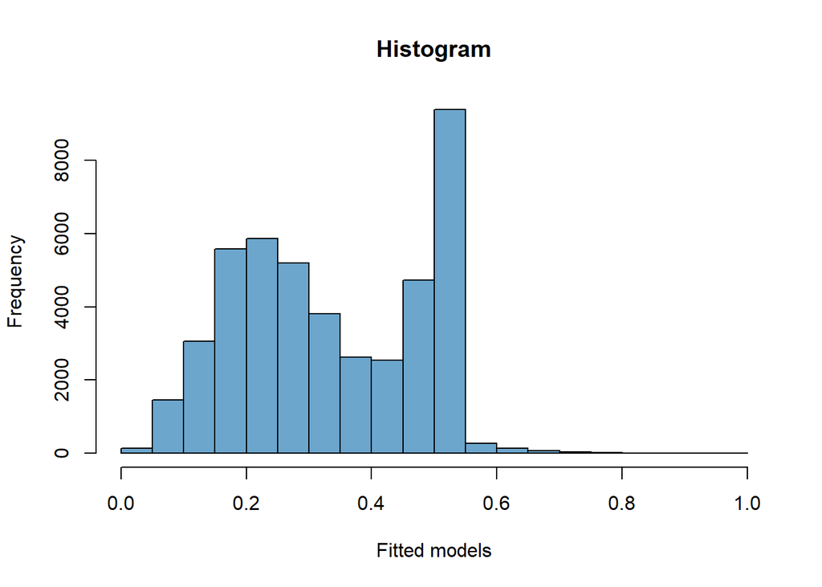

```r
hist(model_2$fitted.values, main = " Histogram ",xlab = "Fitted models", col = 'skyblue3')
```

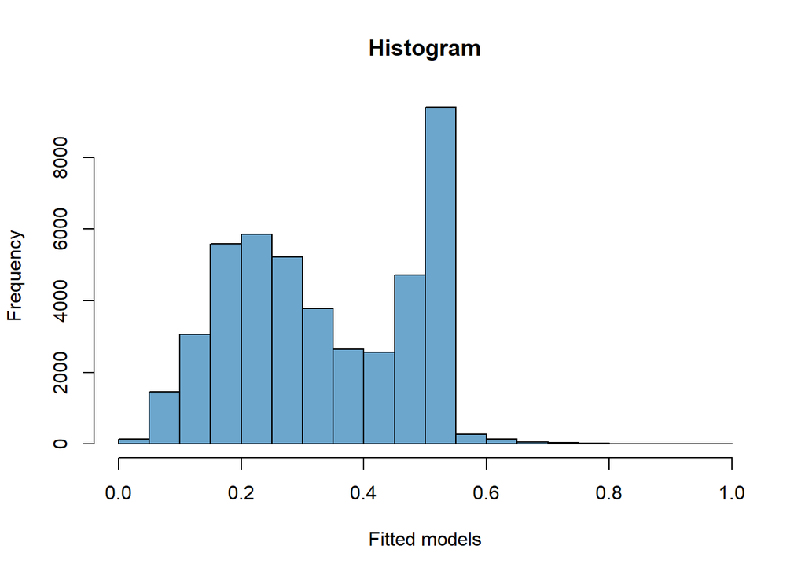

```r
hist(model_2$fitted.values, main = " Histogram ",xlab = "Fitted models", col = 'skyblue3')
```

### Assumptions: Proportional Odds [^6]

Brant Test [^7] The `poTest` function implements tests proposed by Brant (1990) for proportional odds for logistic models fit by the polr() function in the MASS package.

```r
car::poTest(model_2)
```

```r
car::poTest(model_2)
```

```
##
## Tests for Proportional Odds
## polr(formula = euth_risk ~ Type + (Gender + solidcolor + Color1 +
##     MaturitySize + FurLength + Health + Quantity + Fee + PhotoAmt +
##     AgeYears + purebreed + AllMeds), data = train_data, Hess = TRUE)
##
##                           b[polr]   b[>Low] b[>Medium] Chisquare df Pr(>Chisq)
## Overall                                                   440.58 28    < 2e-16
## TypeCat                   0.70478   0.41725    1.12849     70.61  1    < 2e-16
## GenderFemale              0.18315   0.20032    0.16411      0.52  1    0.47280
## GenderMixed               0.08114   0.03422    0.12349      0.90  1    0.34294
## solidcolorYes            -0.11997  -0.04553   -0.18631      6.07  1    0.01373
## Color1Brown              -0.04182  -0.07323   -0.03461      0.43  1    0.51041
## Color1Golden             -0.06930  -0.00351   -0.12762      1.56  1    0.21115
## Color1Yellow              0.10675   0.06017    0.13748      0.47  1    0.49201
## Color1Cream              -0.37114  -0.39661   -0.35605      0.16  1    0.69172
## Color1Gray               -0.13128  -0.08074   -0.19367      0.98  1    0.32221
## Color1White              -0.31767  -0.29927   -0.34353      0.13  1    0.71364
## MaturitySizeMedium        0.18858   0.28504    0.04090     19.11  1    1.2e-05
## MaturitySizeLarge         0.02218  -0.03753    0.01847      0.38  1    0.53963
## MaturitySizeExtra Large  -0.45520  -0.04514   -1.51493      4.37  1    0.03665
## FurLengthMedium          -0.16204  -0.23221   -0.10316      7.04  1    0.00797
## FurLengthLong            -0.82366  -0.77816   -0.81809      0.13  1    0.72092
## HealthMinor Injury        0.28295   0.20631    0.31544      0.76  1    0.38236
## HealthSerious Injury      0.54142   1.12477    0.46010      1.10  1    0.29356
## Quantity                  0.13104   0.12293    0.14231      0.64  1    0.42492
## Fee                       0.00108   0.00092    0.00132      1.55  1    0.21288
## PhotoAmt                 -0.03007   0.01966   -0.08974    176.07  1    < 2e-16
## AgeYears                  0.17398   0.14344    0.20528     10.63  1    0.00111
## purebreedYes             -1.10346  -0.98428   -1.42002     24.51  1    7.4e-07
## AllMeds4                 -0.63740  -0.55348   -0.73626      4.68  1    0.03050
## AllMeds5                 -0.70629  -0.73599   -0.71152      0.08  1    0.77372
## AllMeds6                 -0.87316  -0.89460   -0.87134      0.08  1    0.77472
## AllMeds7                 -0.43666  -0.60416   -0.37693      2.82  1    0.09315
## AllMeds8                 -0.51888  -0.20875   -0.82868     14.81  1    0.00012
## AllMeds9                 -0.20593  -0.60772   -0.02360     33.19  1    8.4e-09
##
## Overall                 ***
## TypeCat                 ***
## GenderFemale
```

[output cut: 13 more lines]

```
## HealthMinor Injury
## HealthSerious Injury
## Quantity
## Fee
## PhotoAmt                ***
## AgeYears                **
## purebreedYes            ***
## AllMeds4                *
## AllMeds5
## AllMeds6
## AllMeds7                .
## AllMeds8                ***
## AllMeds9                ***
## ---
## Signif. codes:  0 '***' 0.001 '**' 0.01 '*' 0.05 '.' 0.1 ' ' 1
```

A significant test statistic provides evidence that the parallel regression assumption has been violated.

## Predictions

```r
evaluation <- read.csv("https://raw.githubusercontent.com/akarimhammoud/Data_621/main/Final%20Project/data/TestData/test_cleaned.csv")
```

After cleaning and selecting the `evalutaion` correpsonding to our `train_data` used in `model_2`, we have:

```r
str(evaluation)
```

[output not shown]

[output cut: 58 more lines]

[output not shown]

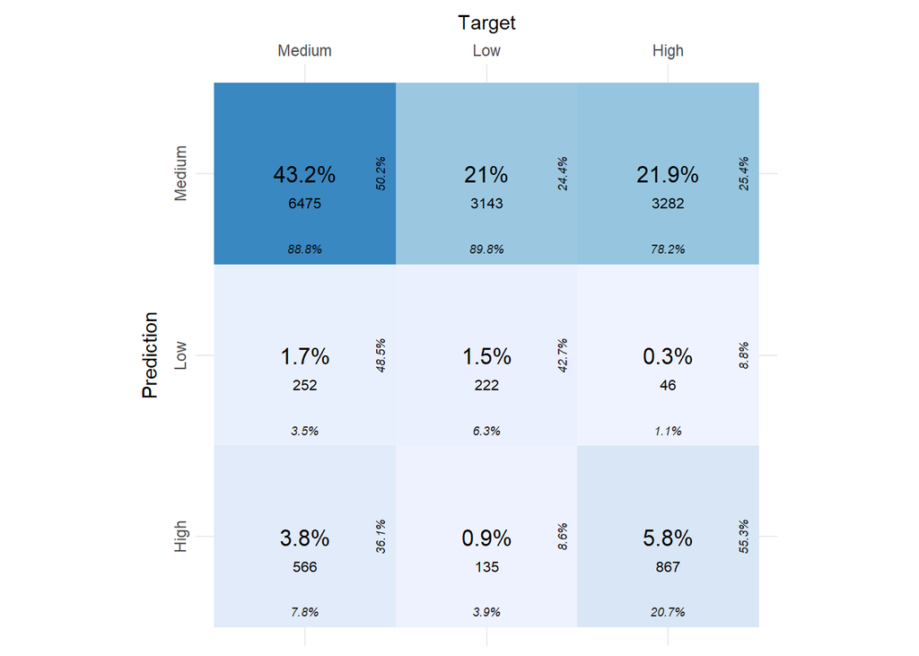

## References

[5.3 Key Assumptions of Ordinal Regression](https://www.restore.ac.uk/srme/www/fac/soc/wie/research-new/srme/modules/mod5/3/index.html)  
[Ordinal Logistic Regression and its Assumptions — Full Analysis](https://medium.com/evangelinelee/ordinal-logistic-regression-on-world-happiness-report-221372709095)  
[Chapter 12 Ordinal Logistic Regression](https://bookdown.org/chua/ber642_advanced_regression/ordinal-logistic-regression.html)  
[Fitting and Interpreting a Proportional Odds Model](https://data.library.virginia.edu/fitting-and-interpreting-a-proportional-odds-model/)  
[How to Perform Ordinal Logistic Regression in R](https://www.r-bloggers.com/2019/06/how-to-perform-ordinal-logistic-regression-in-r/)

[^1]: https://www.nature.com/articles/s41598-021-87649-2
[^2]: https://bmcvetres.biomedcentral.com/articles/10.1186/s12917-020-02728-2
[^3]: https://stats.idre.ucla.edu/r/dae/ordinal-logistic-regression/
[^4]: https://timeseriesreasoning.com/contents/akaike-information-criterion/
[^5]: http://www.sthda.com/english/articles/39-regression-model-diagnostics/160-multicollinearity-essentials-and-vif-in-r/
[^6]: https://www.st-andrews.ac.uk/media/ceed/students/mathssupport/ordinal%20logistic%20regression.pdf
[^7]: https://cehs-research.github.io/eBook_regression/ordered-logistic-regression-ex-spaking.html#assumptions-1
[^8]: https://towardsdatascience.com/implementing-and-interpreting-ordinal-logistic-regression-1ee699274cf5
[^9]: https://cran.r-project.org/web/packages/cvms/vignettes/Creating_a_confusion_matrix.html